# Coursework Report

# Results

Based on the various plots created, we can observe that there appears to be little relationship between the high status story and more choice of the green product, in fact it appears to be in the opposite direction of participants selecting the luxury product in the experimental condition. This is suggested to be true when considering all products and genders together. Within the high-status story condition, 61% of participants chose the luxury product over the green product, compared to 52% in the control story.

TObserved Proportion of product preferences by story condition

|  | Control Story | High-Status Story |
| --- | --- | --- |
| luxury | 52 | 61 |
| green | 48 | 39 |

Contingency tables were also constructed of the observed frequencies of product preferences, which could then be used to form bar graphs and additionally to compare to the expected frequencies created within the Chi-Squared analysis.

Observed Frequencies of car preferences by story condition

|  | Control Story | High-Status Story |
| --- | --- | --- |
| luxury | 36 | 41 |
| green | 27 | 30 |

Observed Frequencies of dishwasher preferences by story condition

|  | Control Story | High-Status Story |
| --- | --- | --- |
| luxury | 33 | 45 |
| green | 30 | 27 |

Observed Frequencies of cleaner preferences by story condition

|  | Control Story | High-Status Story |
| --- | --- | --- |
| luxury | 30 | 46 |
| green | 33 | 26 |

Shown below is a bar chart showing the observed frequencies of product preferences by story conditions and separated by the product type. Here we can see that participants were more likely to choose the luxury product when in the status story condition over all product types.

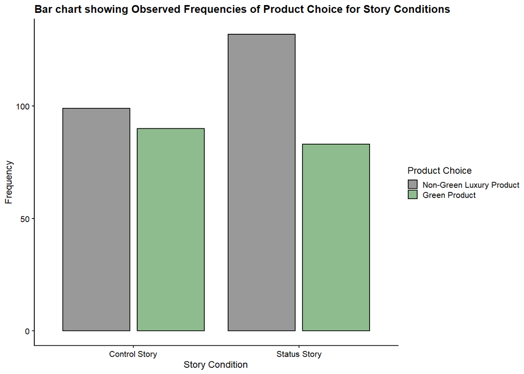

The plot above displays the general trend of participants towards the luxury product over the green product in both story conditions.

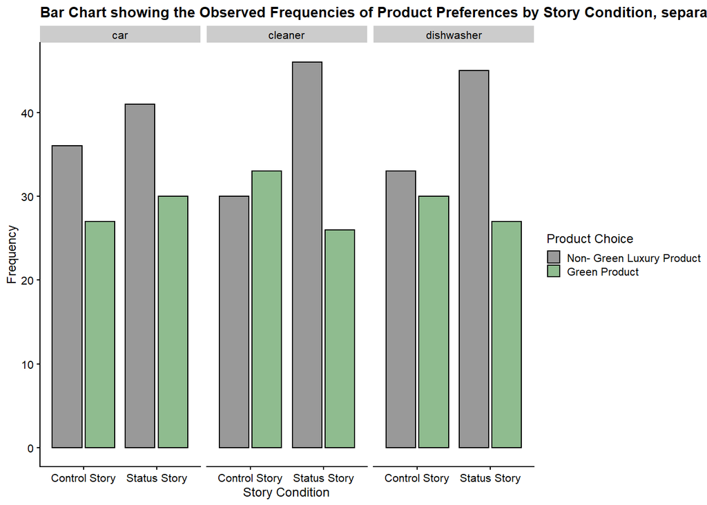

The plot above separates the results by the products, for which all participants were tested. There is a preference for the luxury product within the status story condition.

Using the Chi-Squared statistical analysis with the data, we can form expected frequency tables for each of the products (which reflect the expected frequencies if the null hypothesis is considered to be true). We can compare this expected frequency to the observed frequency, and use the *X*<sup>2</sup> value, the degrees of freedom and the p-value to suggest the extent to which the null hypothesis is likely to occur.

If we split up the data into the products we find different relationships for each, however:

There was not a significant association between story type and product preference for the car products, *X*<sup>2</sup>(1) = 0, *p* = 1. The p-value of 1 suggests that there is no possibility that the null hypothesis is unlikely, therefore 100% supporting the null that there is no relationship between the story type and product preference for car products.

Expected Frequencies of car preferences

|  | Control Story | High-Status Story |
| --- | --- | --- |
| luxury | 36.2 | 40.8 |
| green | 26.8 | 30.2 |

The expected values of preference for car products are almost identical to the observed values, which reflects the truth in the nul hypothesis.

There was not a significant association between story type and product preference for the dishwasher products, *X*<sup>2</sup>(1) = 1.03, *p* = 0.311. The *p* value is small ( = 0.311) however is above the critical value (is we use p < 0.05). This therefore suggests that there is a relatively small relationship between story type and preference for dishwashers.

Expected frequencies of dishwasher preferences

|  | Control Story | High-Status Story |
| --- | --- | --- |
| luxury | 36.4 | 41.6 |
| green | 26.6 | 30.4 |

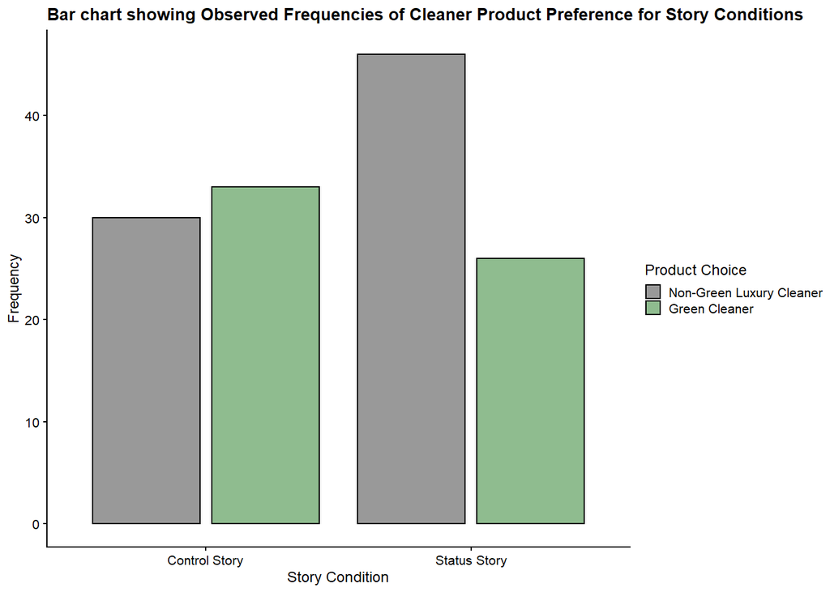